# Compare biomass between years

This code was written by II for the manuscript: https://doi.org/10.1093/icesjms/fsae129 This code is preceded by “Regrid.Rmd” and followed by “Ocean data.Rmd”

# Objective of code

Analysis 1: Are there differences in acoustically detected center of mass depth between years?! (2013-2018)

# Background:

The following code analyzes whether there were any differences in acoustic backscatter and center of mass depth (m) BETWEEN years in our study. We are interested in inter annual differences AND at varying cell sizes (sensitivity analysis for different regridding sizes)

NOTE: - analysis part 1 (this document): Comparing differences in Center of mass depth between years (and diff spatial scales of regridding) - analysis part 2 (Analysis 2.Rmd): which oceanographic variables are likely driving the center of mass depth of the DSL at a regridded distance of 25km

# Load libraries

```r
library(tidyverse) # all things
library(lubridate) # dates
library(sf) # spatial features, mapping
library(multcompView) #cld compact letter display for output
library(rcompanion) # this just helps us complete the mult comp test output so it can be read by mulcompView
library(ggthemes) # simplification of themes for ggplotting
```

# Which re-grid size are you working on?!! MANUAL step

Sensitivity analysis: 1km, 5km, 10km, 15km, 20km (from fine-resolution, 100m data originally output) Need to manually set the dataset here (df are differentiated by grid size as acoustics_regrid_15km for ex) so the following code will all run on the same input

```r
# MANUAL step: select which regridding of acoustics data we are interested in
acoustic_regrid= acoustics_regrid_25km

grid_size="25km" #MANUAL step
```

### MINIMUM number of 100m grid cells required for larger grid size

There are some instances where our re-gridded cell (of whichever scale) were based on 1 or few 100m horizontal cells. Since we are extrapolating these values over a large region, select those cells with at least a minimum of 3 100m fine-resolution cells covering a larger grid cell

```r
# Ensure each cell has at least 3 100m grid cells per re-gridded cell (echo_count)

acoustic_regrid= acoustic_regrid |>
                 filter(echo_count>=3)
```

# set up gridlines (regardless of regrid size) for plotting

```r
# gridlines-- to draw gridlines based on indivdiual gridcell size
#longitude (x axis)
lon1 <- unique(acoustic_regrid$lon_grid_low)
lon2<- unique(acoustic_regrid$lon_grid_hi)
# add on highest value from lon_grid_high
lon=unique(c(lon1, lon2))
lon
```

```
 [1] -124.1760 -123.8852 -123.6015 -123.3178 -123.8825 -123.5997 -123.3169 -123.3159 -123.0339 -123.3150 -123.0338 -122.7527 -123.0337
[14] -122.7534 -122.4731 -122.7541 -122.4746 -122.1951 -122.4761 -122.1974 -123.8906 -123.6052 -123.8879 -123.6034 -124.1724 -123.5979
[27] -122.7548 -123.8934 -123.3188 -123.0342 -123.0341 -123.0340 -122.7512 -122.7519 -122.4699 -122.4715 -122.1904 -122.1927 -121.9125
[40] -121.9156 -123.6071 -123.3208 -123.3198
```

```r
rm(lon1, lon2)

#latitude (y axis)
lat1 <- unique(acoustic_regrid$lat_grid_low)
lat2<- unique(acoustic_regrid$lat_grid_hi)
# add on highest value from lon_grid_high
lat=unique(c(lat1, lat2))
lat
```

```
 [1] 38.17373 37.72565 37.72743 37.72854 37.50033 37.50211 37.50321 37.27786 37.27828 37.05251 37.05293 37.05267 36.82756 36.82731 36.82640
[16] 36.60194 36.60104 36.59948 36.37567 36.37412 38.17624 38.17806 37.95095 37.95275 37.94846 37.27678 36.37657 38.40152 37.95387 37.95429
[31] 37.72896 37.50363 37.50337 37.27803 37.27710 37.05175 37.05017 36.82483 36.82259 36.59726 38.40336 38.40449 38.17918
```

```r
rm(lat1, lat2)
```

# PLOT acoustic track over regridded data– how many fine-resolution cells per re-gridded cell?

#MANUAL: change cell size in geom_point

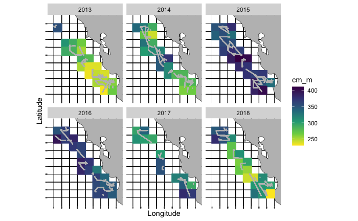

25km: size=7.1 20km: size= 5.2

# Calculate median values for plotting

se=s/sqrt(n) where s= sample standard deviation and n=sample size. in our case, our units here are the # of grid cells per year

```r
# group by year and create summary stats such as median values and se and other labels for boxplot
summary_year <- acoustic_regrid  |>
                group_by(year) |>
                summarize(no_grid_cells=n(),
                          median_MVBS=round(median(MVBS), 2),
                          #median_NASC=round(median(NASC), 5),
                          median_CM=round(median(cm_m)),
                          se_MVBS=sd(MVBS)/sqrt(no_grid_cells),
                          #se_NASC=sd(NASC)/sqrt(no_grid_cells),
                          se_CM=sd(cm_m)/sqrt(no_grid_cells),
                          sd_MVBS=sd(MVBS),
                          #sd_NASC=sd(NASC),
                          sd_CM=sd(cm_m),
                          quantile_mvbs=quantile(MVBS, probs=0.75), #find the 3rd quantile for labeling letters later
                          quantile_cm=quantile(cm_m, probs=0.75))
```

I loaded the library plotrix which has the function std.error as a double check and all values the same so just going with sd()/sqrt(# grid cells)

# MVBS between years (boxplot)

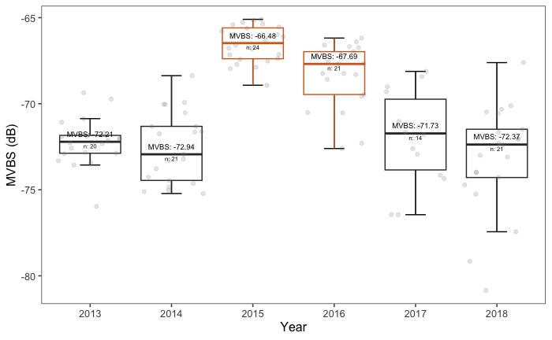

```r
# simple box plot of MVBS values per year
ggplot(data=acoustic_regrid, aes(x=year, y=MVBS), color="black")+
  stat_boxplot(geom="errorbar", width=0.25)+
  geom_boxplot(data=acoustic_regrid, aes(x=year, y=MVBS, color=year), outlier.shape=NA, show.legend = FALSE)+ #plot boxplots without outliers since these are all plotted via geom_jitter
  scale_color_manual(values = c("2013"="grey20", "2014"="grey20", "2015"="chocolate", "2016"="chocolate", "2017"="grey20", "2018"="grey20"))+
  geom_jitter(alpha=0.2, color="snow4")+ #add actual data points to our boxplot
  geom_text(data= summary_year, aes(x = as.factor(year), y = median_MVBS, label = paste0("MVBS: ", median_MVBS)), size = 2.5, vjust = -1)+ #label median
  geom_text(data= summary_year, aes(x = as.factor(year), y = median_MVBS, label = paste0("n: ", no_grid_cells)), size = 2, vjust = 1.5,color="black")+
  xlab("Year")+
  ylab("MVBS (dB)")+
  ggthemes::theme_few()


#save
ggsave(filename=paste0("./plots/analysis 1/boxplot_mvbs_", grid_size, ".pdf"), width=7, height=5, units="in")
```

# CM between years (boxplot)

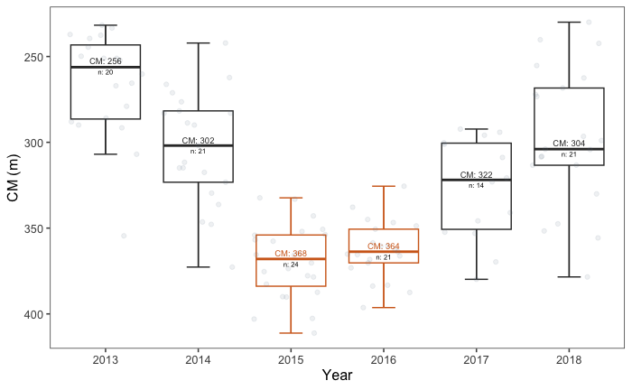

```r
# simple box plot of NASC values
ggplot(data=acoustic_regrid, aes(x=year, y=cm_m, color=year))+
  stat_boxplot(geom="errorbar", width=0.25)+
  geom_boxplot(data=acoustic_regrid, aes(x=year, y=cm_m), outlier.shape=NA, show.legend = FALSE)+ #plot boxplots without outliers since in jitter
  scale_color_manual(values = c("2013"="grey20", "2014"="grey20", "2015"="chocolate", "2016"="chocolate", "2017"="grey20", "2018"="grey20"))+
  geom_jitter(alpha=0.1, color="slategrey")+ #add actual data points to our boxplot
  scale_y_reverse()+
  geom_text(data= summary_year, aes(x = as.factor(year), y = median_CM, label = paste0("CM: ", median_CM)), size = 2.5, vjust = -0.5)+ #label median
  geom_text(data= summary_year, aes(x = as.factor(year), y = median_CM, label = paste0("n: ", no_grid_cells)), size = 2, vjust = 1.5, color="black")+ #label sample size
  xlab("Year")+
  ylab("CM (m)")+
  ggthemes::theme_few()+
  theme(legend.position = 'none')

# save plot to plots folder
ggsave(filename=paste0("./plots/analysis 1/boxplot_cm_", grid_size, ".pdf"), width=7, height=5, units="in")
```

# PLOT: Distribution of MVBS between years

NOTE:using colors from Okabe & Ito (2008)

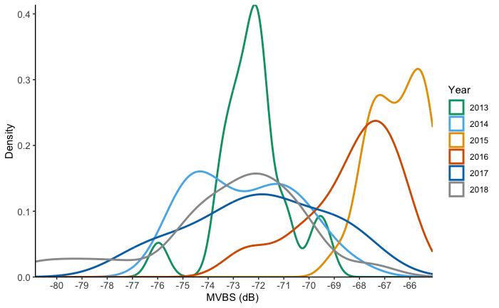

```r
# using binned output (25x25km)
ggplot(data = acoustic_regrid, aes(x=MVBS, colour=year))+
  #geom_histogram(aes(y=..density..),color="grey", fill="transparent", binwidth = 50)+ #this is plotting properly for some reason
  geom_density(alpha=0.2, fill="NA", linewidth=1)+ #plot density curves
  scale_color_manual(values = c("2013"="#009E73" , "2014"= "#56B4E9", "2015"="#E69F00", "2016"="#D55E00" , "2017"= "#0072B2", "2018"= "#999999"))+
  scale_x_continuous(expand=c(0,0), breaks = round(seq(min(acoustic_regrid$MVBS), max(acoustic_regrid$MVBS), by=1), 0))+ #move plot to axis
  scale_y_continuous(expand = c(0,0))+
  xlab("MVBS (dB) ")+
  ylab("Density")+
  labs(color="Year")+
  theme_classic()+
  theme(axis.text.x = element_text(size=10),
        axis.text.y = element_text(size=10))

ggsave(paste0("./plots/analysis 1/mvbs_bw_years_", grid_size, ".pdf"))
```

plot depicting the full distribution of MVBS values between years!

# Plot the distribution of CM between years

```
Saving 85 x 114 mm image
```

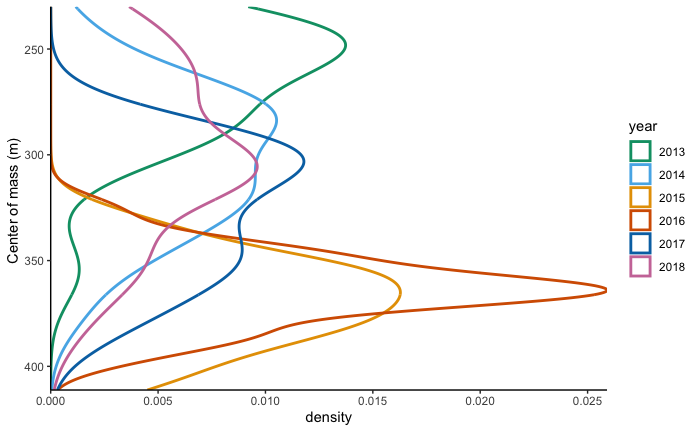

```r
# using binned output (25x25km)


# using binned output (25x25km)
ggplot(data = acoustic_regrid, aes(x=cm_m, colour=year))+
  #geom_histogram(aes(y=..density..),color="grey", fill="transparent", binwidth = 50)+ #this is plotting properly for some reason
  geom_density(alpha=0.2, fill="NA", linewidth=1)+ #plot density curves
  scale_color_manual(values = c("2013"="#009E73", "2014"="#56B4E9", "2015"="#E69F00", "2016"="#D55E00", "2017"="#0072B2", "2018"="#CC79A7"))+
  scale_x_reverse(expand=c(0,0))+ #move plot to axis
  scale_y_continuous(expand = c(0,0))+
  xlab("Center of mass (m) ")+
  coord_flip()+
  theme_classic()


ggsave(paste0("./plots/analysis 1/cm_bw_years_", grid_size, ".pdf"), width=85, units="mm")
```

# Combined plot

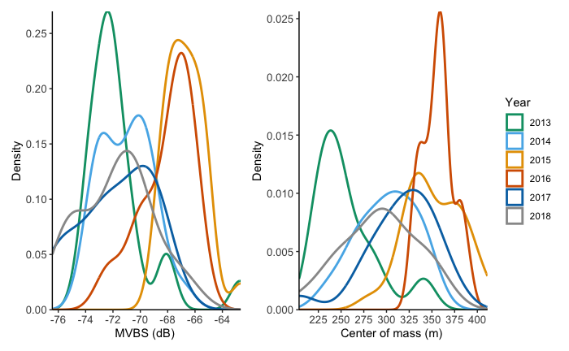

```r
library(patchwork)
p1=ggplot(data = acoustic_regrid, aes(x=MVBS, colour=year))+
  #geom_histogram(aes(y=..density..),color="grey", fill="transparent", binwidth = 50)+ #this is plotting properly for some reason
  geom_density(alpha=0.2, fill="NA", linewidth=1, show.legend = FALSE)+ #plot density curves
  scale_color_manual(values = c("2013"="#009E73" , "2014"= "#56B4E9", "2015"="#E69F00", "2016"="#D55E00" , "2017"= "#0072B2", "2018"= "#999999"))+
  scale_x_continuous(expand=c(0,0), breaks = round(seq(min(acoustic_regrid$MVBS), max(acoustic_regrid$MVBS), by=2), 0))+ #move plot to axis
  scale_y_continuous(expand = c(0,0))+
  xlab("MVBS (dB) ")+
  ylab("Density")+
  labs(color="Year")+
  theme_classic()+
  theme(axis.text.x = element_text(size=10),
        axis.text.y = element_text(size=10))
p2=ggplot(data = acoustic_regrid, aes(x=cm_m, colour=year))+
  geom_density(alpha=0.2, fill="NA", linewidth=1)+ #plot density curves
  scale_color_manual(values = c("2013"="#009E73" , "2014"= "#56B4E9", "2015"="#E69F00", "2016"="#D55E00" , "2017"= "#0072B2", "2018"= "#999999"))+
  scale_x_continuous(expand=c(0,0), breaks = round(seq(min(acoustic_regrid$cm_m)-4, max(acoustic_regrid$cm_m)+1, by=25), 0))+ #move plot to axis
  scale_y_continuous(expand = c(0,0))+
  xlab("Center of mass (m) ")+
  ylab("Density")+
  labs(color="Year")+
  theme_classic()+
  theme(axis.text.x = element_text(size=10),
        axis.text.y = element_text(size=10))
p1+p2
ggsave(paste0("./plots/analysis 1/cm_mvbs_dist_combo_", grid_size, ".pdf"), height=5, width=10, units = "in", dpi = 300)
```

# EXPORT plot with black background

This is just for reference

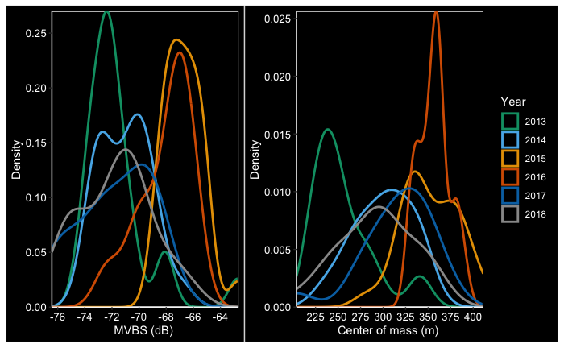

```r
library(patchwork)

# MVBS plot
p1=ggplot(data = acoustic_regrid, aes(x=MVBS, colour=year))+
  #geom_histogram(aes(y=..density..),color="grey", fill="transparent", binwidth = 50)+ #this is plotting properly for some reason
  geom_density(alpha=0.2, fill="NA", linewidth=1, show.legend = FALSE)+ #plot density curves
  scale_color_manual(values = c("2013"="#009E73" , "2014"= "#56B4E9", "2015"="#E69F00", "2016"="#D55E00" , "2017"= "#0072B2", "2018"= "#999999"))+
  scale_x_continuous(expand=c(0,0), breaks = round(seq(min(acoustic_regrid$MVBS), max(acoustic_regrid$MVBS), by=2), 0))+ #move plot to axis
  scale_y_continuous(expand = c(0,0))+
  xlab("MVBS (dB) ")+
  ylab("Density")+
  labs(color="Year")+
  theme_classic()+
  theme(axis.text.x = element_text(size=10, color="white"),
        axis.text.y = element_text(size=10, color="white"),
        panel.background = element_rect(fill = 'black', color="white"),
        plot.background = element_rect(fill='black', color="white"),
        panel.grid.major = element_blank(),
        panel.grid.minor = element_blank(),
        legend.background = element_rect(fill='transparent'),
        legend.box.background=element_rect(fill = 'transparent'),
        legend.text = element_text(color = "white"),
        legend.title = element_text(color="white"),
        axis.line = element_line(color = "white"),
        axis.title = element_text(color="white"))


# center of mass plot
p2=ggplot(data = acoustic_regrid, aes(x=cm_m, colour=year))+
  geom_density(alpha=0.2, fill="NA", linewidth=1)+ #plot density curves
  scale_color_manual(values = c("2013"="#009E73" , "2014"= "#56B4E9", "2015"="#E69F00", "2016"="#D55E00" , "2017"= "#0072B2", "2018"= "#999999"))+
  scale_x_continuous(expand=c(0,0), breaks = round(seq(min(acoustic_regrid$cm_m)-4, max(acoustic_regrid$cm_m)+1, by=25), 0))+
  scale_y_continuous(expand = c(0,0))+
  xlab("Center of mass (m) ")+
  ylab("Density")+
  labs(color="Year")+
  theme_classic()+
  theme(axis.text.x = element_text(size=10, color="white"),
        axis.text.y = element_text(size=10, color="white"),
        panel.background = element_rect(fill = 'black', color="white"),
        plot.background = element_rect(fill='black', color="white"),
        panel.grid.major = element_blank(),
        panel.grid.minor = element_blank(),
        legend.background = element_rect(fill='transparent'),
        legend.box.background=element_rect(fill = 'transparent'),
        legend.text = element_text(color = "white"),
        legend.title = element_text(color="white"),
        axis.line = element_line(color = "white"),
        axis.title = element_text(color="white"))

p1+p2
ggsave(paste0("./plots/analysis 1/cm_mvbs_dist_combo_", grid_size, "_clear.pdf"), height=5, width=10, units = "in", dpi = 300, bg="transparent")
```

# STATISTICAL TEST: KRUSKAL WALLIS

From Conover 1999: The following Assumptions are required: 1. All samples are random samples from their respective populations. 2. In addition to independence within each sample, there is mutual independence among the various samples. 3. The measurement scale is at least ordinal 4. Either the k population distribution functions are identical, or else some of the populations tend to yield larger values than other populations do.

Hypotheses: H0: all of the K population distribution functions are identical H1: At least one of the populations tends to yield larger observations than at least one of the other populations alt H1: The k populations do not all have identical means

# convert year to a factor

```r
# first ensure that year is a factor
acoustic_regrid$year <- as.factor(acoustic_regrid$year)
levels(acoustic_regrid$year) #check on order of factor year (all good in sequential order)
```

```
[1] "2013" "2014" "2015" "2016" "2017" "2018"
```

# Kruskall Wallis test: MVBS and CM between years

# MANUAL step

Make sure to change the grid cell size when storing output

```r
# MANUAL OUTPUT -- save output for grid size

# Kruskal wallis test-- MVBS
kw_mvbs= kruskal.test(MVBS ~ year, data = acoustic_regrid)
kw_mvbs
```

```
    Kruskal-Wallis rank sum test

data:  MVBS by year
Kruskal-Wallis chi-squared = 74.996, df = 5, p-value = 9.321e-15
```

```r
#MANUAL: save output per grid size
kw_mvbs_25km=kw_mvbs


# Kruskal wallis test--- CM
kw_cm= kruskal.test(cm_m ~ year, data = acoustic_regrid)
kw_cm
```

```
    Kruskal-Wallis rank sum test

data:  cm_m by year
Kruskal-Wallis chi-squared = 76.209, df = 5, p-value = 5.203e-15
```

```r
#MANUAL: save output per grid size
kw_cm_25km=kw_cm
```

If p-value <0.05 we can conclude that there are significant differences between groups (years). In order to know which pairs of years were different, we must further test with multiple comparisons.

# MUTLIPLE COMPARISONS– Kruskal Wallis

Although we know there are differences between years, we don’t know between WHICH years these differences occur. To compare between groups (years) we thus additionally need to make pairwise comparisons.

Background: “If, and only if the null hypothesis is rejected, we may we use the following procedure to determine which pairs of populations tend to differ” uses rank-sum Conover

NOTE: default value for multiple comparisons is “BH” for Bejamini & Hochberg. see p.adjust for more info. Bonferonni conservative option

#MANUAL

```r
# multiple comparisons test-- MVBS
kw_mc_mvbs= pairwise.wilcox.test(acoustic_regrid$MVBS, acoustic_regrid$year,
                 p.adjust.method = "bonferroni")
kw_mc_mvbs
```

```
    Pairwise comparisons using Wilcoxon rank sum exact test

data:  acoustic_regrid$MVBS and acoustic_regrid$year

     2013    2014    2015    2016    2017
2014 1.0000  -       -       -       -
2015 1.7e-11 1.6e-11 -       -       -
2016 3.1e-06 2.4e-06 0.0044  -       -
2017 1.0000  1.0000  1.2e-08 0.0013  -
2018 1.0000  1.0000  9.5e-11 5.3e-06 1.0000

P value adjustment method: bonferroni
```

```r
# MANUAL: save output per grid cell size
kw_mc_mvbs_25km= kw_mc_mvbs



# multiple comparisons test-- CM
kw_mc_cm= pairwise.wilcox.test(acoustic_regrid$cm_m, acoustic_regrid$year,
                 p.adjust.method = "bonferroni")

# MANUAL: save output per grid cell size
kw_mc_cm_25km= kw_mc_cm

# to see p-values:
format(kw_mc_cm$p.value, scientific = FALSE)
```

```
     2013                 2014                 2015                 2016                 2017
2014 "0.0086050249516903" "                NA" "                NA" "                NA" "                NA"
2015 "0.0000000007665928" "0.0000000278721767" "                NA" "                NA" "                NA"
2016 "0.0000000033441220" "0.0000005165553784" "1.0000000000000000" "                NA" "                NA"
2017 "0.0000259702820661" "0.6073288825657898" "0.0010434648687678" "0.0090944263938412" "                NA"
2018 "0.0826592992184075" "1.0000000000000000" "0.0000002257519118" "0.0000035945410033" "0.9154247311396916"
```

# Data for compact letter display (cld) via {rcompanion} to complete output table and {multcompView} for creating the CLD

compact lettering display Compact letter display allows us color significant differences in our data

```r
#Take our p.value output from Pairwise.Wilcoxon.Text (ie mutliple comparisons for kruskall wallis)

kw_mc_cm
```

```
    Pairwise comparisons using Wilcoxon rank sum exact test

data:  acoustic_regrid$cm_m and acoustic_regrid$year

     2013    2014    2015    2016    2017
2014 0.0086  -       -       -       -
2015 7.7e-10 2.8e-08 -       -       -
2016 3.3e-09 5.2e-07 1.0000  -       -
2017 2.6e-05 0.6073  0.0010  0.0091  -
2018 0.0827  1.0000  2.3e-07 3.6e-06 0.9154

P value adjustment method: bonferroni
```

```r
kw_mc_mvbs
```

```
    Pairwise comparisons using Wilcoxon rank sum exact test

data:  acoustic_regrid$MVBS and acoustic_regrid$year

     2013    2014    2015    2016    2017
2014 1.0000  -       -       -       -
2015 1.7e-11 1.6e-11 -       -       -
2016 3.1e-06 2.4e-06 0.0044  -       -
2017 1.0000  1.0000  1.2e-08 0.0013  -
2018 1.0000  1.0000  9.5e-11 5.3e-06 1.0000

P value adjustment method: bonferroni
```

```r
# select for our p-value output- table of P-values for pairwise comparisons
table_cm= kw_mc_cm$p.value
table_mvbs= kw_mc_mvbs$p.value

#convert these tables into "full" tables ie not just NA using package rcompaniion
kw_mc_cm_full = rcompanion::fullPTable(table_cm)
kw_mc_mvbs_full = rcompanion::fullPTable(table_mvbs)


# calculate CLD
cld_cm= multcompView::multcompLetters(kw_mc_cm_full)
cld_mvbs= multcompView::multcompLetters(kw_mc_mvbs_full)

# display groupings
cld_cm
```

```
2013 2014 2015 2016 2017 2018
 "a"  "b"  "c"  "c"  "b" "ab"
```

```r
cld_mvbs
```

```
2013 2014 2015 2016 2017 2018
 "a"  "a"  "b"  "c"  "a"  "a"
```

```r
# add these values to our summary_year table
summary_year= summary_year |>
  mutate(cld_cm=as.vector(cld_cm$Letters), cld_mvbs=as.vector(cld_mvbs$Letters))

#remove intermediary steps
rm(kw_mc_cm_full, kw_mc_mvbs_full, table_cm, table_mvbs)
```

# References on adding output from multiple comparisons to boxplot

see https://r-graph-gallery.com/84-tukey-test a little complicated https://statdoe.com/one-way-anova-and-box-plot-in-r/

# Add multipe comparisons letters to boxplot – MVBS

color blind friendly palette

#MANUAL: adjust color ramp and position of letters within circles :)

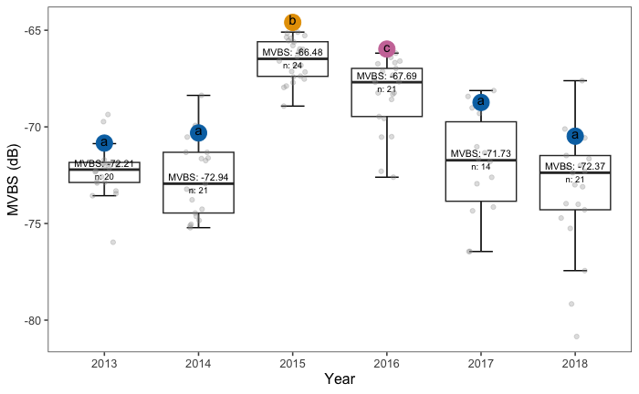

```r
# simple box plot of MVBS values- multiple comparison results from KW
ggplot(data=acoustic_regrid, aes(x=year, y=MVBS))+
  stat_boxplot(geom="errorbar", width=0.25)+ #error bars
  geom_boxplot(data=acoustic_regrid, aes(x=year, y=MVBS), outlier.shape=NA)+ #plot boxplots without outliers since in jitter
  geom_jitter( width=0.15, height=0, alpha=0.3, color="#999999" )+ #add actual data points to our boxplot don't jitter in vertical direction and close toge horiz
  geom_text(data= summary_year, aes(x = year, y = median_MVBS, label = paste0("MVBS: ", median_MVBS)), size = 2.8, vjust = -0.5)+ #label median
  geom_text(data= summary_year, aes(x = year, y = median_MVBS, label = paste0("n: ", no_grid_cells)), size = 2.5, vjust = 1.5, color="black")+ #n
  geom_point(data = summary_year, aes(x = year, y = quantile_mvbs+1, label = cld_mvbs, color=cld_mvbs), size=6, alpha=1, show.legend = FALSE)+ # label cld
  geom_text(data = summary_year, aes(x = year, y = quantile_mvbs, label = cld_mvbs), vjust=-1.8, color="black")+ # label significance cl adjust position
  scale_color_manual(values=clrs)+ #use manual color palette defined above
  xlab("Year")+
  ylab("MVBS (dB)")+
  theme(legend.position = 'none')+
  ggthemes::theme_few()
```

[output not shown]

Play around with the position of letters and circles, they shift with each cell size (eye roll) Also vary when exported 25km: vjust= -2.2 20km: vjust= -1.7 15km: vjust= -1.4 10km: vjust= -1.3 5km: vjust= -1.4 1km: vjust= -1.3

# Same plot but transparent background

for presentations with a black background

```r
ggplot(data=acoustic_regrid, aes(x=year, y=MVBS))+
  stat_boxplot(geom="errorbar", width=0.25, color="white")+
  geom_boxplot(data=acoustic_regrid, aes(x=year, y=MVBS), fill=NA, color="white", outlier.shape=NA)+ #plot boxplots without outliers since in jitter
  geom_jitter( width=0.15, height=0, alpha=0.3, color="#999999" )+ #add actual data points to our boxplot don't jitter in vertical
  geom_text(data= summary_year, aes(x = year, y = median_MVBS, label = paste0("MVBS: ", median_MVBS)), size = 2.8, vjust = -0.5, color="white")+ #label median
  geom_text(data= summary_year, aes(x = year, y = median_MVBS, label = paste0("n: ", no_grid_cells)), size = 2.5, vjust = 1.5, color="white")+ #n
  geom_point(data = summary_year, aes(x = year, y = quantile_mvbs+1, label = cld_mvbs, color=cld_mvbs), size=6, alpha=1, show.legend = FALSE)+ # label cld
  geom_text(data = summary_year, aes(x = year, y = quantile_mvbs, label = cld_mvbs), vjust=-2.2, color="white")+ # label significance cl
  scale_color_manual(values=clrs)+ #use manual color palette defined above
  xlab("Year")+
  ylab("MVBS (dB)")+
  theme(legend.position = 'none')+
  ggthemes::theme_few()+
  theme(legend.position = 'none',
        panel.background = element_rect(fill = 'transparent', color="white"),
        plot.background = element_rect(fill='transparent', color="white"),
        panel.grid.major = element_blank(),
        panel.grid.minor = element_blank(),
        legend.background = element_rect(fill='transparent'),
        legend.box.background=element_rect(fill = 'transparent'),
        axis.text = element_text(colour="white"),
        axis.line = element_line(color = "white"),
        axis.title = element_text(color="white"))


ggsave(filename=paste0("./plots/analysis 1/boxplot_kw_mc_mvbs_transparent_", grid_size, "_.pdf"), width=7, height=5, units="in", bg="transparent")
# Add multiple comparisons to boxplot -- CM
```

[output not shown]

# # Add multipe comparisons letters to boxplot – CM

```r
#set up MANUAL color scale for letters (manually change inputs to match cld output)
clrs= unique(summary_year$cld_cm)
clrs # run this to see unique output per grid size
```

```
[1] "a"  "b"  "c"  "ab"
```

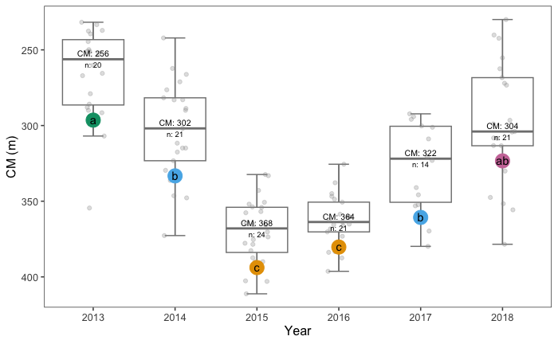

```r
clrs = c(
"a" = "#009E73",
"b" = "#56B4E9",
"c" = "#E69F00",
"ab"= "#CC79A7"
)

# manually set some color-blind freindly colors and manually update labels depending on unique combinations

# simple box plot of CM values- multiple comparison results from KW
ggplot(data=acoustic_regrid, aes(x=year, y=cm_m, color=year))+
  stat_boxplot(geom="errorbar", width=0.25)+
  geom_boxplot(data=acoustic_regrid, aes(x=year, y=cm_m), outlier.shape=NA)+ #plot boxplots without outliers since in jitter
  #scale_color_manual(values = c("2013"="grey20", "2014"="grey20", "2015"="chocolate", "2016"="chocolate", "2017"="grey20", "2018"="grey20"))+
  geom_jitter(width=0.15, height=0, alpha=0.3, color="#999999" )+ #add actual data points to our boxplot
  geom_text(data= summary_year, aes(x = year, y = median_CM, label = paste0("CM: ", median_CM)), size = 2.8, vjust = -0.5, color="black")+ #label median
  geom_text(data= summary_year, aes(x = year, y = median_CM, label = paste0("n: ", no_grid_cells)), size = 2.5, vjust = 1.5, color="black")+ #n
  geom_point(data = summary_year, aes(x = year, y = quantile_cm+10, label = cld_cm, color=cld_cm), size=6, alpha=1)+ # label cld
  geom_text(data = summary_year, aes(x = year, y = quantile_cm, label = cld_cm), vjust=2.2, color="black")+ # label significance cld
  scale_color_manual(values=clrs)+ #use manual color palette defined above
  scale_y_reverse()+
  xlab("Year")+
  ylab("CM (m)")+
  ggthemes::theme_few()+
  theme(legend.position = 'none')
ggsave(filename=paste0("./plots/analysis 1/boxplot_kw_mc_cm_jitter_", grid_size, "_.pdf"), width=170, height=119, units="mm", bg="transparent")
```

25km: vjust= 2.1 20km: vjust= 2.1 15km: vjust= 2.1 10km: vjust= 2.0 5km: vjust= 2.0 1km: vjust= 1.8 NOTE: also exported with more intuitive color scheme (orginal also exported with underscore original_color_)

# Same plot but transparent background

for presentations with black backgrounds

```r
ggplot(data=acoustic_regrid, aes(x=year, y=cm_m, color=year))+
  stat_boxplot(geom="errorbar", width=0.25, color="white")+
  geom_boxplot(data=acoustic_regrid, aes(x=year, y=cm_m), outlier.shape=NA, fill=NA, color="white")+ #plot boxplots without outliers since in jitter
  #scale_color_manual(values = c("2013"="grey20", "2014"="grey20", "2015"="chocolate", "2016"="chocolate", "2017"="grey20", "2018"="grey20"))+
   geom_jitter(width=0.15, height=0, alpha=0.3, color="#999999" )+ #add actual data points to our boxplot
  geom_text(data= summary_year, aes(x = year, y = median_CM, label = paste0("CM: ", median_CM)), size = 2.8, vjust = -0.5, color="white")+ #label median
  geom_text(data= summary_year, aes(x = year, y = median_CM, label = paste0("n: ", no_grid_cells)), size = 2.5, vjust = 1.5, color="white")+ #n
  geom_point(data = summary_year, aes(x = year, y = quantile_cm+10, label = cld_cm, color=cld_cm), size=6, alpha=1)+ # label cld
  geom_text(data = summary_year, aes(x = year, y = quantile_cm, label = cld_cm), vjust=2.1, color="white")+ # label significance cld
  scale_color_manual(values=clrs)+ #use manual color palette defined above
  scale_y_reverse()+
  xlab("Year")+
  ylab("CM (m)")+
  ggthemes::theme_few()+
  theme(legend.position = 'none')+
  theme(legend.position = 'none',
        panel.background = element_rect(fill = 'transparent', color="white"),
        plot.background = element_rect(fill='transparent', color="white"),
        panel.grid.major = element_blank(),
        panel.grid.minor = element_blank(),
        legend.background = element_rect(fill='transparent'),
        legend.box.background=element_rect(fill = 'transparent'),
        axis.text = element_text(colour="white"),
        axis.line = element_line(color = "white"),
        axis.title = element_text(color="white"))

ggsave(filename=paste0("./plots/analysis 1/boxplot_kw_mc_cm_transparent", grid_size, "_.pdf"), width=7, height=5, units="in")
```

[output not shown]

# For sensitivity analysis, re-run for each of the additional grid cell sizes

1km, 5km, 10km, 15km, 20km, 25km

# When complete, move to Ocean data.Rmd (for extracting ocean data), then satellite.Rmd (satellite light data), Ocean regrid.Rmd (regridding ocean data)